# Assignment10_MA

Akshita

2024-04-23

```r
library(MASS)
library(ggplot2)
library(memisc)
library(ROCR)
#library(dplyr)
#library(klaR)

fish_data <- read.csv("C:/Users/HP/Desktop/USA/Spring'24/Multivariate/Datasets/Fish_dataset.csv")
dim(fish_data)
```

```
## [1] 158   7
```

```r
str(fish_data)
```

```
## 'data.frame':    158 obs. of  7 variables:
##  $ Species: chr  "Bream" "Bream" "Bream" "Bream" ...
##  $ Weight : num  242 290 340 363 430 450 500 390 450 500 ...
##  $ Length1: num  23.2 24 23.9 26.3 26.5 26.8 26.8 27.6 27.6 28.5 ...
##  $ Length2: num  25.4 26.3 26.5 29 29 29.7 29.7 30 30 30.7 ...
##  $ Length3: num  30 31.2 31.1 33.5 34 34.7 34.5 35 35.1 36.2 ...
##  $ Height : num  11.5 12.5 12.4 12.7 12.4 ...
##  $ Width  : num  4.02 4.31 4.7 4.46 5.13 ...
```

```r
fish_independent <- as.matrix(fish_data[,c(2:7)])
fish_raw <- cbind(fish_independent, as.numeric(as.factor(fish_data$Species))-1)
colnames(fish_raw)[7] <- "Species"

smp_size_raw <- floor(0.75 * nrow(fish_raw))
train_ind_raw <- sample(nrow(fish_raw), size = smp_size_raw)
train_raw.df <- as.data.frame(fish_raw[train_ind_raw, ])
test_raw.df <- as.data.frame(fish_raw[-train_ind_raw, ])

fish_raw.lda <- lda(formula = train_raw.df$Species ~ ., data = train_raw.df)
fish_raw.lda
```

```
## Call:
## lda(train_raw.df$Species ~ ., data = train_raw.df)
##
## Prior probabilities of groups:
##          0          1          2          3          4          5          6
## 0.25423729 0.06779661 0.32203390 0.12711864 0.11864407 0.06779661 0.04237288
##
## Group means:
##     Weight  Length1  Length2  Length3    Height    Width
## 0 610.1667 30.19667 32.99333 38.23667 15.139563 5.444193
## 1 163.5000 19.03750 20.67500 23.15000  9.106975 3.267950
## 2 358.8000 24.95789 27.05263 28.67895  7.623421 4.593255
## 3 653.2000 41.22000 44.12000 47.26667  7.509473 4.907500
## 4 177.1429 21.36429 23.03571 25.90000  6.936136 3.811579
## 5  12.5250 11.66250 12.41250 13.51250  2.301588 1.404362
## 6 529.2000 28.86000 31.38000 34.38000  9.883800 5.255260
##
## Coefficients of linear discriminants:
##                   LD1          LD2          LD3           LD4          LD5
## Weight   0.0003923146 -0.004354095  0.004944928  0.0005006089 -0.007703755
## Length1  0.4848515352 -0.623510099  2.701099968  0.7213158351  1.971971703
## Length2  2.1976730007 -0.769478255 -3.781929273  1.2321437064 -1.456197792
## Length3 -2.4619075609  1.840472476  1.086749288 -1.6992484914 -0.262468762
## Height  -1.0394220279 -0.701707588 -0.273961670  0.9481498828  0.339851099
## Width    1.3387076939 -0.963263032 -0.544302100 -2.4265439373  0.149528732
##                 LD6
## Weight  -0.00188583
## Length1 -2.96866712
## Length2  2.75561687
## Length3  0.10188257
## Height  -0.13850297
## Width   -0.32322516
##
## Proportion of trace:
##    LD1    LD2    LD3    LD4    LD5    LD6
## 0.7652 0.1906 0.0283 0.0134 0.0025 0.0000
```

```r
summary(fish_raw.lda)
```

```
##         Length Class  Mode
## prior    7     -none- numeric
## counts   7     -none- numeric
## means   42     -none- numeric
## scaling 36     -none- numeric
## lev      7     -none- character
## svd      6     -none- numeric
## N        1     -none- numeric
## call     3     -none- call
## terms    3     terms  call
## xlevels  0     -none- list
```

```r
print(fish_raw.lda)
```

```
## Call:
## lda(train_raw.df$Species ~ ., data = train_raw.df)
##
## Prior probabilities of groups:
##          0          1          2          3          4          5          6
## 0.25423729 0.06779661 0.32203390 0.12711864 0.11864407 0.06779661 0.04237288
##
## Group means:
##     Weight  Length1  Length2  Length3    Height    Width
## 0 610.1667 30.19667 32.99333 38.23667 15.139563 5.444193
## 1 163.5000 19.03750 20.67500 23.15000  9.106975 3.267950
## 2 358.8000 24.95789 27.05263 28.67895  7.623421 4.593255
## 3 653.2000 41.22000 44.12000 47.26667  7.509473 4.907500
## 4 177.1429 21.36429 23.03571 25.90000  6.936136 3.811579
## 5  12.5250 11.66250 12.41250 13.51250  2.301588 1.404362
## 6 529.2000 28.86000 31.38000 34.38000  9.883800 5.255260
##
## Coefficients of linear discriminants:
##                   LD1          LD2          LD3           LD4          LD5
## Weight   0.0003923146 -0.004354095  0.004944928  0.0005006089 -0.007703755
## Length1  0.4848515352 -0.623510099  2.701099968  0.7213158351  1.971971703
## Length2  2.1976730007 -0.769478255 -3.781929273  1.2321437064 -1.456197792
## Length3 -2.4619075609  1.840472476  1.086749288 -1.6992484914 -0.262468762
## Height  -1.0394220279 -0.701707588 -0.273961670  0.9481498828  0.339851099
## Width    1.3387076939 -0.963263032 -0.544302100 -2.4265439373  0.149528732
##                 LD6
## Weight  -0.00188583
## Length1 -2.96866712
## Length2  2.75561687
## Length3  0.10188257
## Height  -0.13850297
## Width   -0.32322516
##
## Proportion of trace:
##    LD1    LD2    LD3    LD4    LD5    LD6
## 0.7652 0.1906 0.0283 0.0134 0.0025 0.0000
```

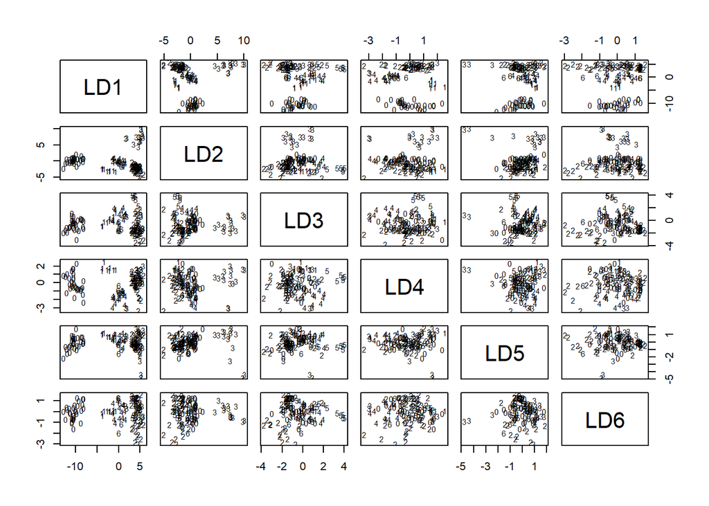

```r
plot(fish_raw.lda)
```

```r
fish_raw.lda.predict <- predict(fish_raw.lda, newdata = test_raw.df)
fish_raw.lda.predict$class
```

```
##  [1] 0 0 0 0 0 4 4 4 4 4 6 1 1 1 2 2 2 2 2 2 2 2 2 2 2 2 2 2 2 2 2 2 3 3 5 5 5 5
## [39] 5 5
## Levels: 0 1 2 3 4 5 6
```

```r
fish_raw.lda.predict$x
```

```
##            LD1         LD2         LD3         LD4         LD5          LD6
## 1   -9.5356185  0.63033492  0.54939487  0.11610991  0.68416708 -0.211729268
## 2   -9.0742669  1.34649199  0.91446269  1.78389581  0.57678363 -0.305328089
## 3   -9.6630930  0.35137237  1.00577860  0.25936285 -0.57196975 -0.663805415
## 4  -10.7915914  0.72966699 -1.34262690  0.38127232 -0.70513526  0.662311652
## 5  -11.2815450 -0.60015063 -1.34538237  1.41004179 -1.72445755  0.164225981
## 6    1.7795791 -0.89164073  0.71195167 -0.82009320 -0.46322627  1.294319452
## 7    1.5911227 -0.32753816  1.12728091 -1.39651877  0.08279422  0.658052635
## 8    2.1494623 -1.68004640  1.23280191 -1.24636951  0.58957787 -0.252702690
## 9    1.8361119 -0.91534572  1.10671100 -0.50719603  0.81822647 -0.264476070
## 10   1.2410207 -0.02825042  1.44655210 -0.26135903  0.86907555 -0.206619277
## 11   1.5314463 -2.48357092 -1.59378341 -3.34944373 -0.25317865 -0.513429477
## 12  -0.2902753 -3.87085217  1.49164491  1.82409042  0.27523546  0.140401897
## 13  -1.3599798 -2.07425797  0.36780557  1.09559286  0.68964441  0.321818143
## 14  -3.0013113 -2.31626178  0.03769815  1.94697328  1.20380793 -0.089361637
```

[output cut: 26 more lines]

```r
#Filter the dataset for the two classes you want to predict
class_1 <- "Bream"  # class 1
class_2 <- "Pike"   # class 2

filtered_data <- fish_data[fish_data$Species %in% c(class_1, class_2), ]
str(filtered_data)
```

```
## 'data.frame':    52 obs. of  7 variables:
##  $ Species: chr  "Bream" "Bream" "Bream" "Bream" ...
##  $ Weight : num  242 290 340 363 430 450 500 390 450 500 ...
##  $ Length1: num  23.2 24 23.9 26.3 26.5 26.8 26.8 27.6 27.6 28.5 ...
##  $ Length2: num  25.4 26.3 26.5 29 29 29.7 29.7 30 30 30.7 ...
##  $ Length3: num  30 31.2 31.1 33.5 34 34.7 34.5 35 35.1 36.2 ...
##  $ Height : num  11.5 12.5 12.4 12.7 12.4 ...
##  $ Width  : num  4.02 4.31 4.7 4.46 5.13 ...
```

```r
fish_independent_new <- as.matrix(filtered_data[,c(2:7)])
fish_raw_new <- cbind(fish_independent_new, as.numeric(as.factor(filtered_data$Species))-1)
colnames(fish_raw_new)[7] <- "Species"

smp_size_raw_new <- floor(0.75 * nrow(fish_raw_new))
train_ind_raw_new <- sample(nrow(fish_raw_new), size = smp_size_raw_new)
train_raw.df_new <- as.data.frame(fish_raw_new[train_ind_raw_new, ])
test_raw.df_new <- as.data.frame(fish_raw_new[-train_ind_raw_new, ])

fish_raw.lda_new <- lda(formula = train_raw.df_new$Species ~ ., data = train_raw.df_new)
fish_raw.lda_new
```

```
## Call:
## lda(train_raw.df_new$Species ~ ., data = train_raw.df_new)
##
## Prior probabilities of groups:
##         0         1
## 0.6923077 0.3076923
##
## Group means:
##     Weight  Length1  Length2  Length3    Height    Width
## 0 624.0370 30.22593 33.05926 38.28519 15.186007 5.440804
## 1 861.9167 45.09167 48.28333 51.67500  8.188608 5.384567
##
## Coefficients of linear discriminants:
##                  LD1
## Weight  -0.001874666
## Length1  0.127194496
## Length2  1.743998811
## Length3 -1.571045453
## Height  -0.897620459
## Width    1.010475863
```

```r
summary(fish_raw.lda_new)
```

```
##         Length Class  Mode
## prior    2     -none- numeric
## counts   2     -none- numeric
## means   12     -none- numeric
## scaling  6     -none- numeric
## lev      2     -none- character
## svd      1     -none- numeric
## N        1     -none- numeric
## call     3     -none- call
## terms    3     terms  call
## xlevels  0     -none- list
```

```r
print(fish_raw.lda_new)
```

```
## Call:
## lda(train_raw.df_new$Species ~ ., data = train_raw.df_new)
##
## Prior probabilities of groups:
##         0         1
## 0.6923077 0.3076923
##
## Group means:
##     Weight  Length1  Length2  Length3    Height    Width
## 0 624.0370 30.22593 33.05926 38.28519 15.186007 5.440804
## 1 861.9167 45.09167 48.28333 51.67500  8.188608 5.384567
##
## Coefficients of linear discriminants:
##                  LD1
## Weight  -0.001874666
## Length1  0.127194496
## Length2  1.743998811
## Length3 -1.571045453
## Height  -0.897620459
## Width    1.010475863
```

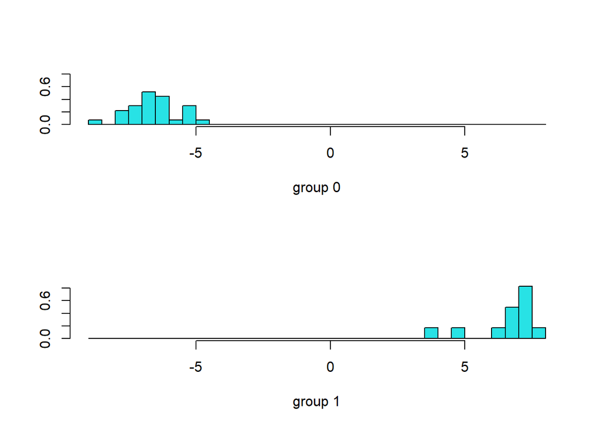

```r
plot(fish_raw.lda_new)
```

```r
fish_raw.lda.predict_new <- predict(fish_raw.lda_new, newdata = test_raw.df_new)
fish_raw.lda.predict_new$class
```

```
##  [1] 0 0 0 0 0 0 0 0 1 1 1 1 1
## Levels: 0 1
```

```r
fish_raw.lda.predict_new$x
```

```
##           LD1
## 5   -2.362586
## 10  -4.507453
## 11  -3.836284
## 13  -3.528194
## 14  -3.145092
## 22  -4.614133
## 31  -5.335310
## 33  -5.529124
## 130  6.676603
## 131  8.699481
## 132  8.329353
## 133  8.835466
## 137 10.069104
```

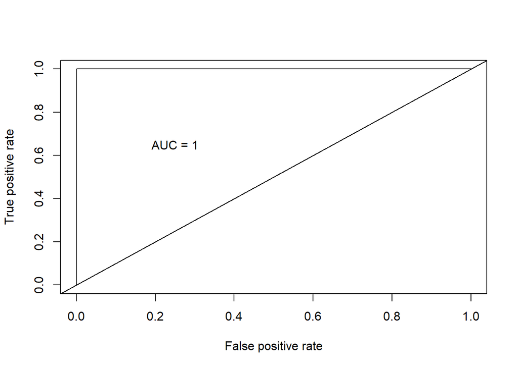

```r
# Get the posteriors as a dataframe.
fish_raw.lda.predict_new.posteriors <- as.data.frame(fish_raw.lda.predict_new$posterior)

pred <- prediction(fish_raw.lda.predict_new.posteriors[,2], test_raw.df_new$Species)
roc.perf = performance(pred, measure = "tpr", x.measure = "fpr")
auc.train <- performance(pred, measure = "auc")
auc.train <- auc.train@y.values
plot(roc.perf)
abline(a=0, b= 1)
text(x = .25, y = .65 ,paste("AUC = ", round(auc.train[[1]],3), sep = ""))
```

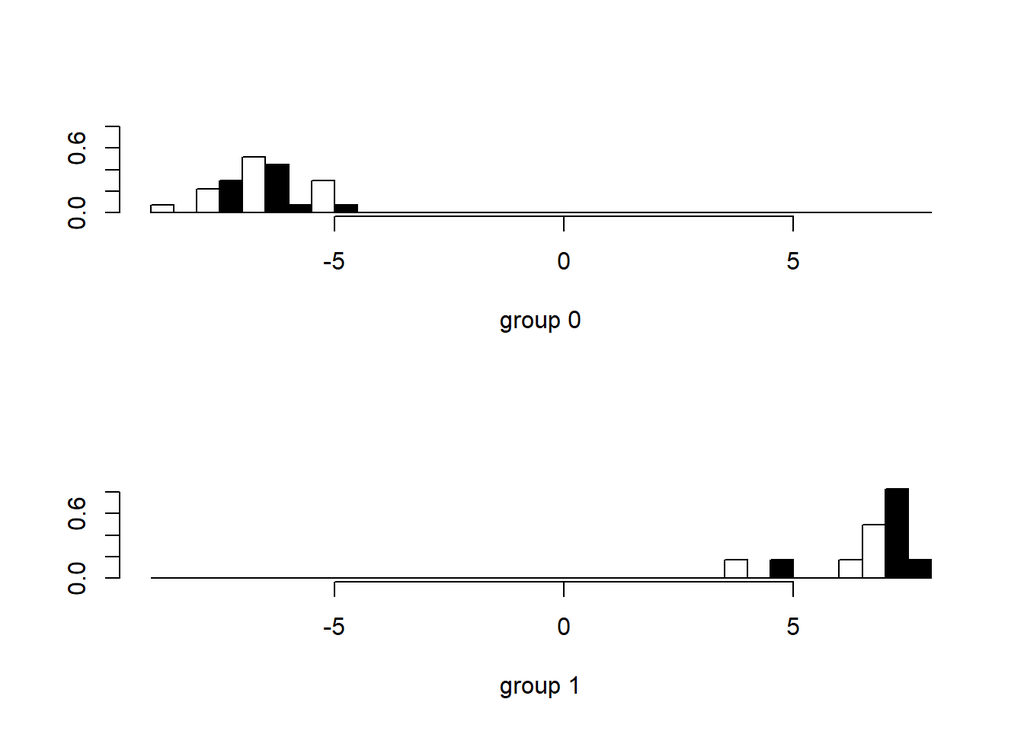

```r
# do a quick plot to understand how good the model is
plot(fish_raw.lda_new, col = as.integer(train_raw.df_new$Species))
```

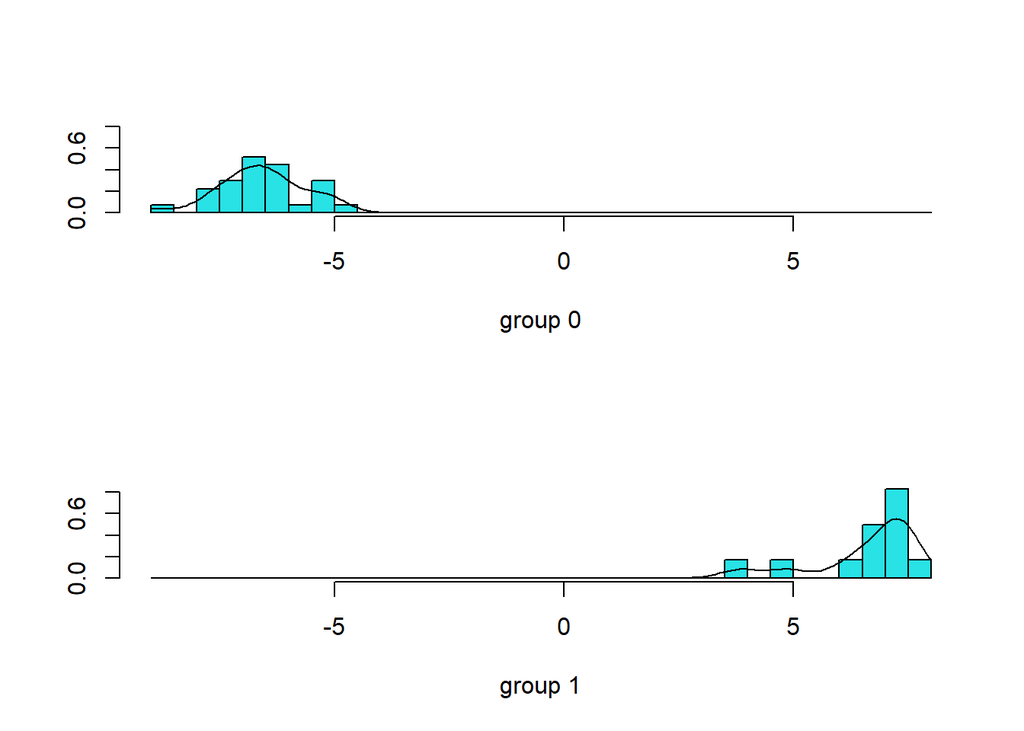

```r
# Sometime bell curves are better
plot(fish_raw.lda_new, dimen = 1, type = "b")
```

```r
# THis plot shows the essense of LDA. It puts everything on a line and finds cutoffs.
# Partition plots
#partimat(Species ~ Weigth + Sepal.Width + Length1 + Length2 + Length3 + Height + Width, data=train_raw.df_new, method="lda")

#Trying with 3 species now
class_3 <- "Roach"
filtered_data_2 <- fish_data[fish_data$Species %in% c(class_1, class_2, class_3), ]

r2 <- lda(formula = Species ~ ., data = filtered_data_2, CV = TRUE)
r2
```

```
## $class
##  [1] Bream Bream Bream Bream Bream Bream Bream Bream Bream Bream Bream Bream
## [13] Bream Bream Bream Bream Bream Bream Bream Bream Bream Bream Bream Bream
## [25] Bream Bream Bream Bream Bream Bream Bream Bream Bream Bream Bream Roach
## [37] Roach Roach Roach Roach Roach Roach Roach Roach Roach Roach Roach Roach
## [49] Roach Roach Roach Roach Roach Roach Pike  Pike  Pike  Pike  Pike  Pike
## [61] Pike  Pike  Pike  Pike  Pike  Pike  Pike  Pike  Pike  Pike  Pike
## Levels: Bream Pike Roach
##
## $posterior
##            Bream         Pike        Roach
## 1   1.000000e+00 2.012119e-34 1.034783e-17
## 2   1.000000e+00 3.023242e-39 1.309972e-21
## 3   1.000000e+00 4.187242e-34 2.363360e-15
## 4   1.000000e+00 8.571696e-33 4.040802e-19
## 5   1.000000e+00 1.057995e-31 3.727808e-13
## 6   1.000000e+00 2.241225e-38 9.002227e-23
## 7   1.000000e+00 1.754800e-38 1.180891e-18
## 8   1.000000e+00 7.686246e-34 4.677437e-19
## 9   1.000000e+00 1.771285e-41 3.796832e-23
## 10  1.000000e+00 4.262150e-45 1.096383e-24
## 11  1.000000e+00 1.134951e-40 1.527319e-23
## 12  1.000000e+00 1.864686e-43 7.791601e-25
## 13  1.000000e+00 7.475450e-39 3.582872e-25
## 14  1.000000e+00 1.594487e-35 3.319364e-25
## 15  1.000000e+00 3.364127e-44 5.167962e-24
## 16  1.000000e+00 1.889614e-44 1.977444e-21
## 17  1.000000e+00 3.377824e-43 8.421908e-22
## 18  1.000000e+00 2.350792e-46 3.097307e-25
## 19  1.000000e+00 8.032351e-45 6.266719e-27
## 20  1.000000e+00 3.602933e-35 1.500904e-14
## 21  1.000000e+00 7.403420e-41 8.384097e-25
## 22  1.000000e+00 1.099417e-46 1.677517e-25
## 23  1.000000e+00 3.680007e-42 5.183707e-29
## 24  1.000000e+00 1.051560e-39 9.492887e-23
## 25  1.000000e+00 6.237664e-48 1.338342e-31
## 26  1.000000e+00 3.966749e-50 5.015657e-31
## 27  1.000000e+00 3.404188e-46 2.817395e-25
## 28  1.000000e+00 7.592836e-46 2.819333e-31
## 29  1.000000e+00 3.678071e-49 6.003500e-26
```

[output cut: 64 more lines]

```
## attr(,".Environment")
## <environment: R_GlobalEnv>
## attr(,"predvars")
## list(Species, Weight, Length1, Length2, Length3, Height, Width)
## attr(,"dataClasses")
##     Species      Weight     Length1     Length2     Length3      Height
## "character"   "numeric"   "numeric"   "numeric"   "numeric"   "numeric"
##       Width
##   "numeric"
##
## $call
## lda(formula = Species ~ ., data = filtered_data_2, CV = TRUE)
##
## $xlevels
## named list()
```

```r
head(r2$class)
```

```
## [1] Bream Bream Bream Bream Bream Bream
## Levels: Bream Pike Roach
```

```r
train <- sample(1:150, 75)
r3 <- lda(Species ~ ., # training model
           filtered_data_2,
           prior = c(1,1,1)/3,
           subset = train)
plda = predict(object = r3, # predictions
                newdata = filtered_data_2[-train, ])
head(plda$class)
```

```
## [1] Bream Bream Bream Bream Bream Bream
## Levels: Bream Pike Roach
```

```r
head(plda$posterior, 6) # posterior prob.
```

```
##   Bream         Pike        Roach
## 1     1 9.117760e-31 1.089290e-16
## 3     1 1.222513e-28 6.717167e-13
## 4     1 1.697441e-26 1.332566e-16
## 6     1 2.190978e-33 1.992680e-20
## 7     1 1.083233e-32 5.376709e-16
## 9     1 4.567448e-40 4.378027e-23
```

```r
head(plda$x, 3)
```

```
##         LD1        LD2
## 1 -5.622985 -1.3087816
## 3 -5.191417 -0.4355947
## 4 -4.970919 -2.2326394
```

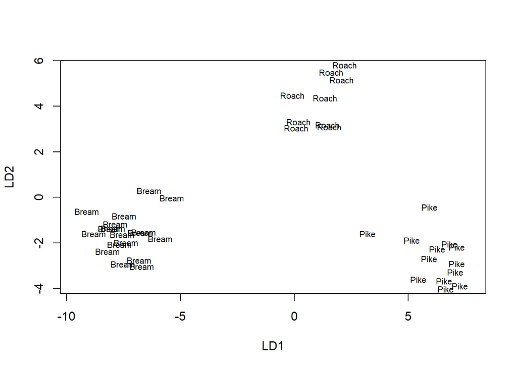

```r
plot(r3)
```

```r
head(r2$posterior, 3)
```

```
##   Bream         Pike        Roach
## 1     1 2.012119e-34 1.034783e-17
## 2     1 3.023242e-39 1.309972e-21
## 3     1 4.187242e-34 2.363360e-15
```

```r
train <- sample(1:150, 75)
r3 <- lda(Species ~ ., # training model
           filtered_data_2,
           prior = c(1,1,1)/3,
           subset = train)
plda = predict(object = r3, # predictions
                newdata = filtered_data_2[-train, ])
head(r2$posterior, 3)
```

```
##   Bream         Pike        Roach
## 1     1 2.012119e-34 1.034783e-17
## 2     1 3.023242e-39 1.309972e-21
## 3     1 4.187242e-34 2.363360e-15
```

```r
head(plda$posterior, 6) # posterior prob.
```

```
##   Bream          Pike        Roach
## 3     1  3.754914e-99 5.671762e-19
## 4     1  3.358115e-83 6.511427e-21
## 5     1  1.237312e-94 9.009188e-17
## 7     1 2.165049e-107 5.754365e-24
## 8     1  3.130329e-87 2.467641e-22
## 9     1 5.878447e-108 5.026213e-30
```

```r
head(plda$x, 3)
```

```
##         LD1        LD2
## 3 -9.148945 -1.1326761
## 4 -7.346542 -3.1553937
## 5 -8.695169 -0.9591351
```

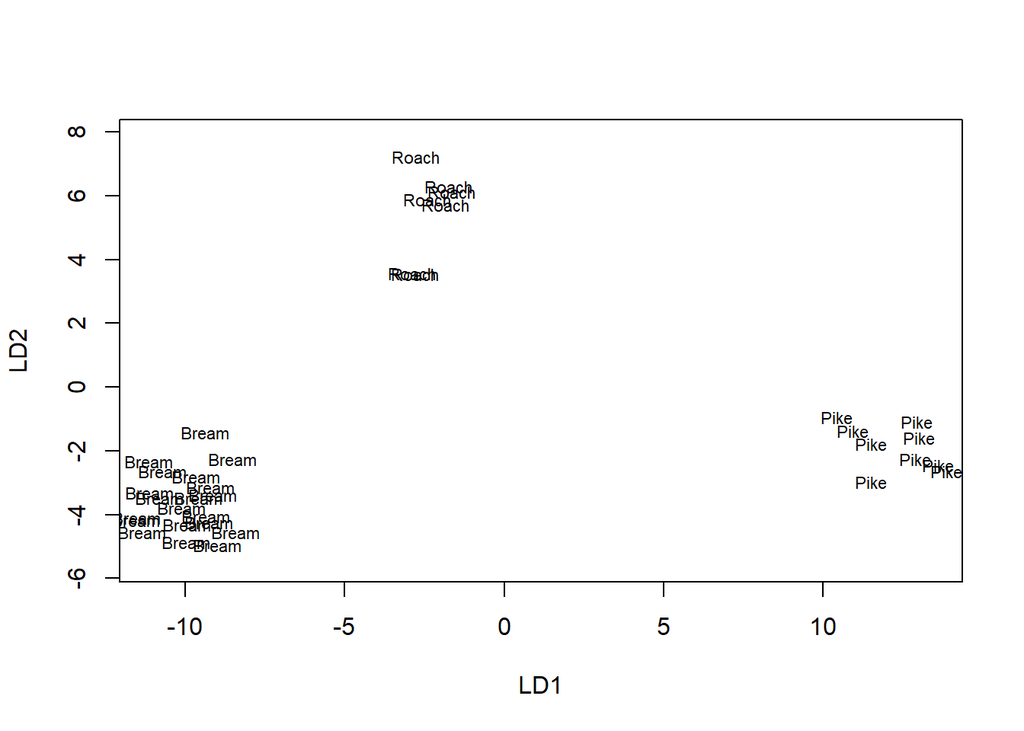

```r
plot(r3)
```

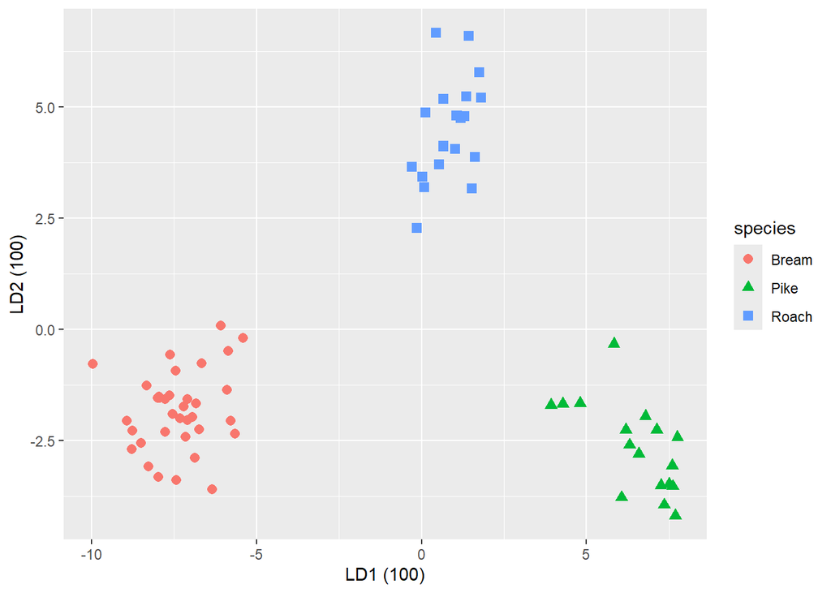

```r
r <- lda(Species ~ .,
          filtered_data_2,
          prior = c(1,1,1)/3)
prop.lda = r$svd^2/sum(r$svd^2)
plda <- predict(object = r,
               newdata = filtered_data_2)
dataset = data.frame(species = filtered_data_2[,"Species"],lda = plda$x)
ggplot(dataset) + geom_point(aes(lda.LD1, lda.LD2, colour = species, shape = species), size = 2.5) + labs(x = paste("LD1 (", percent(prop.lda[1]), ")", sep=""),y = paste("LD2 (", percent(prop.lda[2]), ")", sep=""))
```

```r
# Lets focus on accuracy. Table function
lda.train <- predict(fish_raw.lda_new)
train_raw.df_new$lda <- lda.train$class
table(train_raw.df_new$lda,train_raw.df_new$Species)
```

```
##
##      0  1
##   0 27  0
##   1  0 12
```

```r
# running accuracy on the training set shows how good the model is. It is not an indication of "true" accuracy. We will use the test set to approximate accuracy
lda.test <- predict(fish_raw.lda_new,test_raw.df_new)
test_raw.df_new$lda <- lda.test$class
table(test_raw.df_new$lda,test_raw.df_new$Species)
```

```
##
##     0 1
##   0 8 0
##   1 0 5
```

Prior Probabilities:

Prior probabilities represent the relative frequencies of each fish species in the training data.

Group Means:

Proportion of Trace:

Proportion of trace indicates the amount of variance explained by each discriminant function.

This suggests that LD1 is the most informative discriminant function for separating fish species based on morphological measurements.

This indicates that group 0 is more prevalent in the data compared to group 1.

LD1 scores represent the values obtained by projecting the new data onto the discriminant function derived from the training data.

Higher LD1 scores typically indicate a stronger association with the predicted class.

Observations with higher LD1 scores are more confidently assigned to class 1, while those with lower LD1 scores are assigned to class 0.

Accuracy:

Training Set Performance:

Test Set Performance:

These results suggest that the model trained using the new data (fish_raw.lda_new) performs exceptionally well on both the training and test datasets, with 100% accuracy in classification for both sets. However, it’s important to note that the test set here is relatively small, so generalization to larger datasets should be considered carefully.